# Inference and Prediction of Country from Facebook Confessions Forums

Adrian Naranjo

# Part 1: Introduction & Descriptive Analysis

### Confession pages are…

- Social networking websites
- Used at schools and universities
- Students post thoughts, questions, secrets to the community
- Anonymous

### How much data?

| country | num_observations |
| --- | --- |
| United States | 78608 |
| Canada | 68000 |
| United Kingdom | 5000 |

### Date Range (Year)

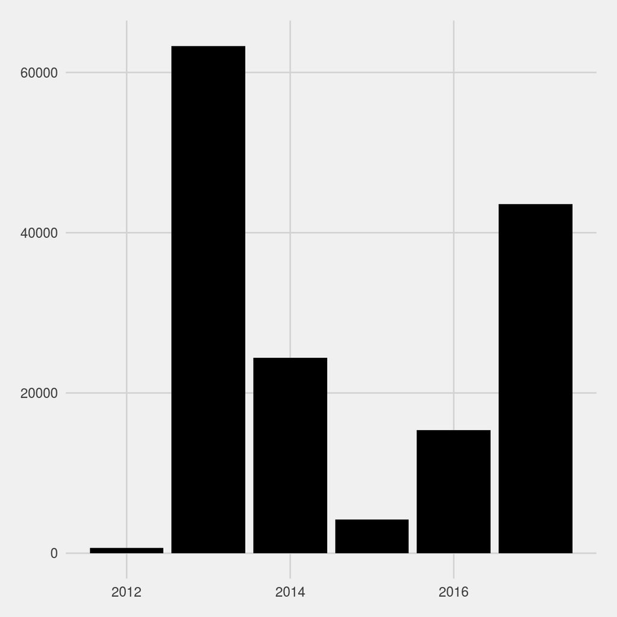

### US Regions/States with Most Posts

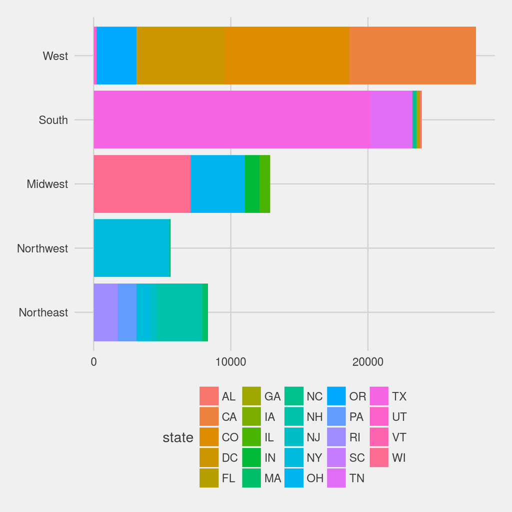

### Universities with the Most Posts

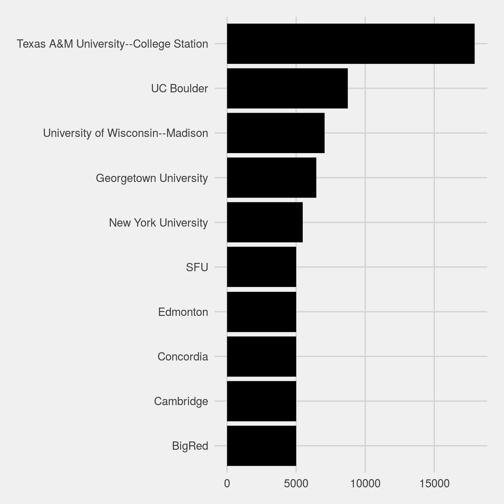

### Range of Posts for the Universities

```
##    0%   25%   50%   75%  100%
##     1    24   427  4500 17938
```

### What [raw] variables?

- Datetime
- Post
- Number of Likes
- Number of Comments
- University
- Country

### Variables have we added?

- Separated Datetime into: Year, month, day
- Number of Words
- Number of Characters
- Characters per Word
- I-Word Count
- I-Word Percent of Total Words
- You-Word Count
- You-Word Percent of Total Words
- I-Word to U-Word Ratio
- Stop Word Count
- Stop Word Percent of Total Words
- Region
- State

#### I-Words = I, I’ve, I’d, I’ll, I’m

#### You-Words = You, You’ve, You’d, You’ll, You’re

### Most Narcissistic Schools

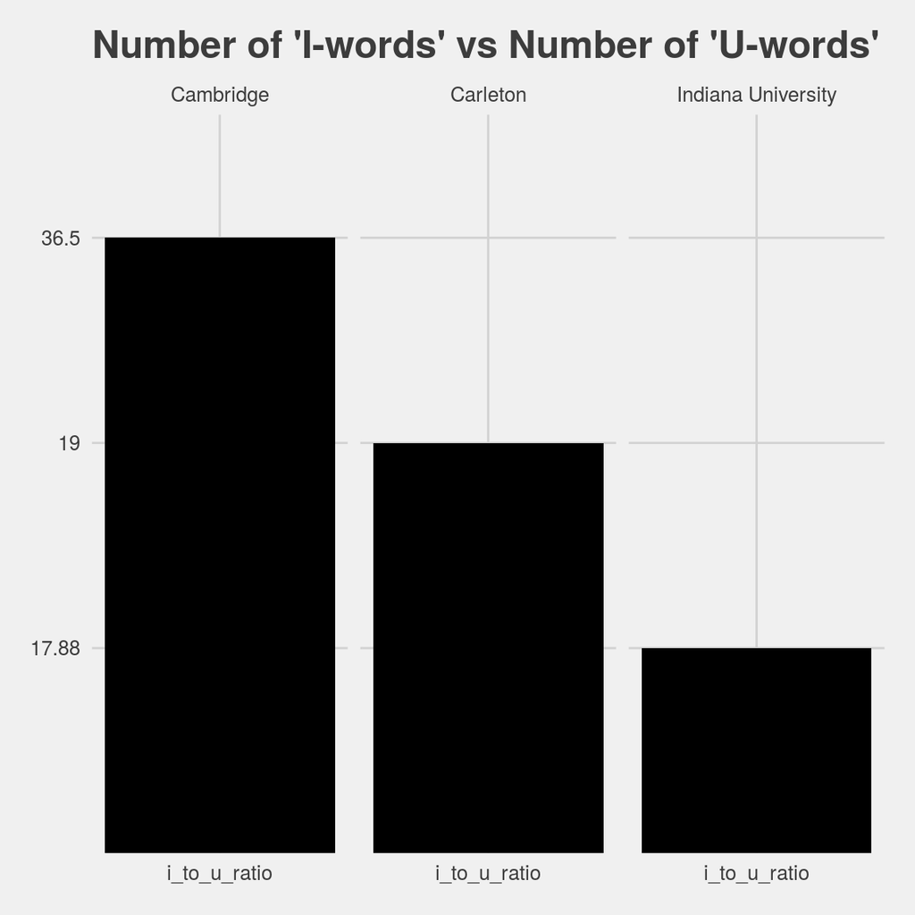

### Most Altruistic Schools

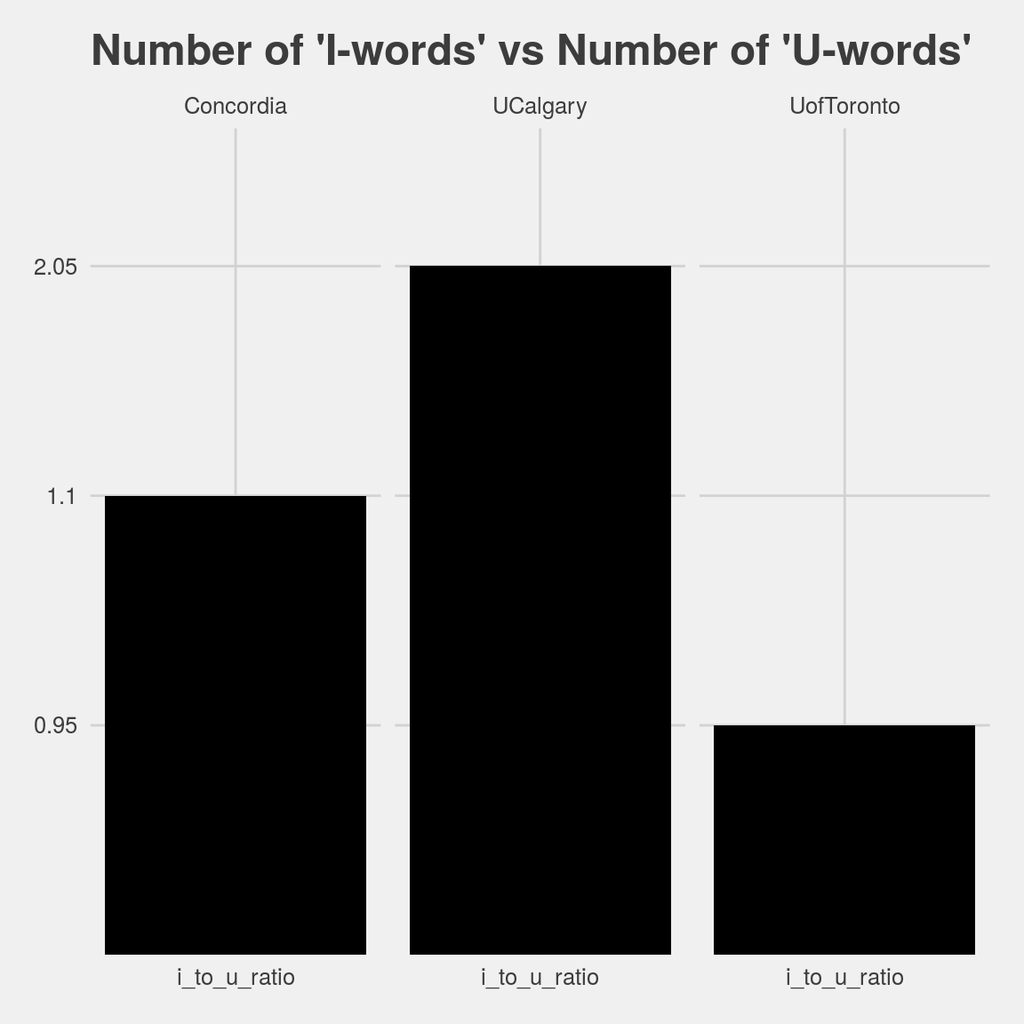

### Average Number of Words

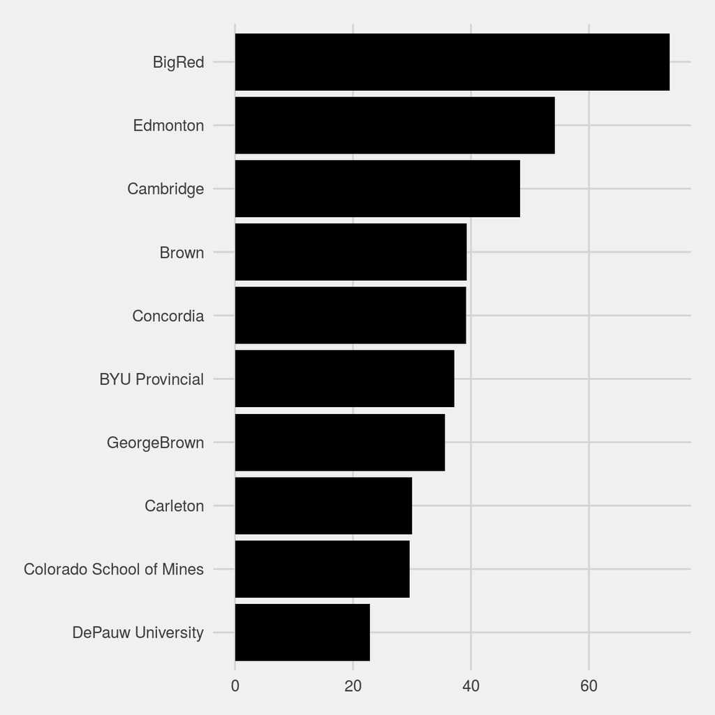

### Average Characters per Word

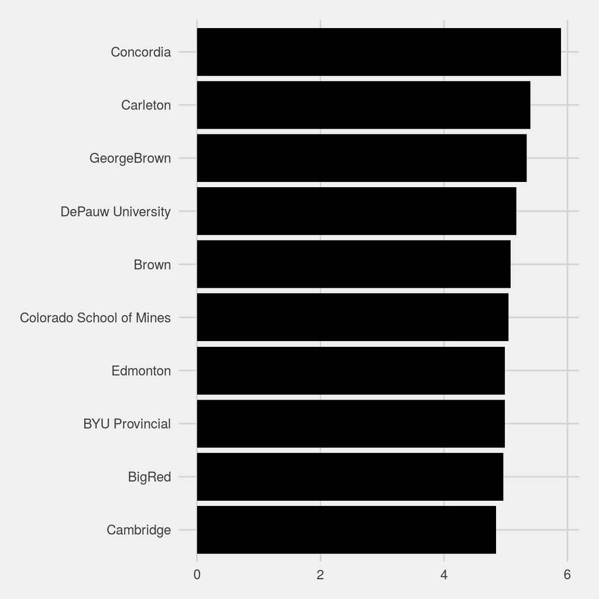

# Part 2: Sentiment Analysis

Preprocessing included:

1. Removal of stopwords, punctuation, whitespace
2. Removal of words with a sparsity greater than 99%
   - Led to reduction of words from 42,961 words to 393 words
3. Added 3 sentiment libraries: afinn, bing, and nrc
   - We’ll focus on nrc, but afinn and bing are left in for use in prediction and unsurpervised learning

### Most Used Words

| term | count | perc |
| --- | --- | --- |
| know | 33308 | 0.0220 |
| peopl | 30470 | 0.0201 |
| time | 28859 | 0.0190 |
| feel | 28562 | 0.0188 |
| confess | 27534 | 0.0182 |
| guy | 23232 | 0.0153 |
| friend | 22966 | 0.0151 |
| girl | 22412 | 0.0148 |
| realli | 21097 | 0.0139 |
| year | 20903 | 0.0138 |

### Sentiments

- Anger
- Anticipation
- Disgust
- Fear
- Negative
- Positive
- Joy
- Sadness
- Surprise
- Trust

### Negative versus Positive Sentiments

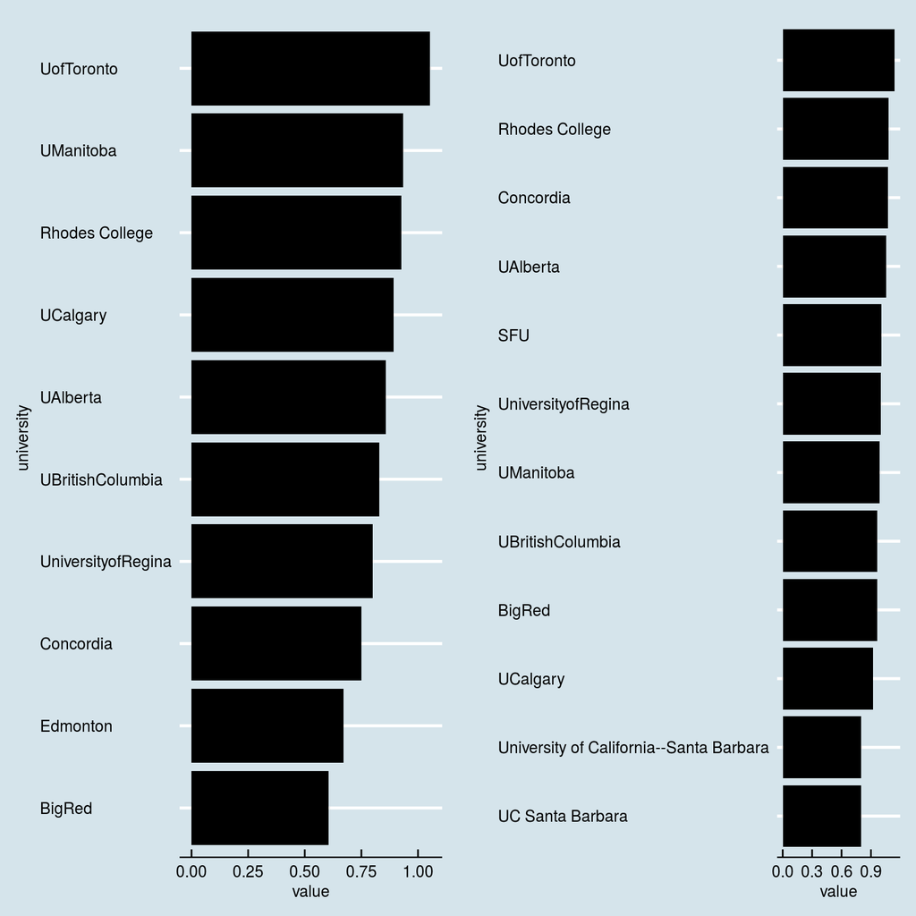

### Misc Negative Sentiments

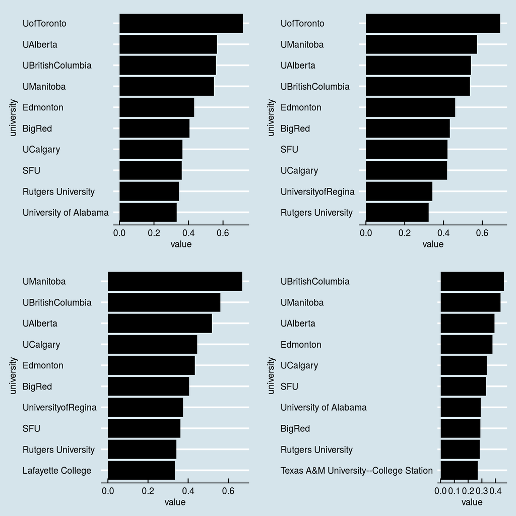

### Misc Positive Sentiments

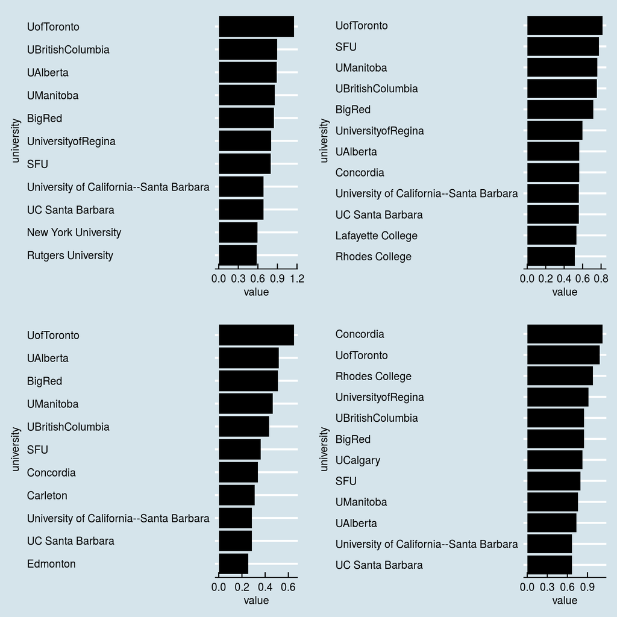

# Part 3: Prediction

#### Note: Only the below parameters were used:

- Number of Likes
- Number of Comments
- Number of Words
- Number of Characters
- Characters per Word
- I-Word Count
- I-Word Percent of Total Words
- You-Word Count
- You-Word Percent of Total Words
- I-Word to U-Word Ratio
- Stop Word Count
- Stop Word Percent of Total Words
- Sentiment libraries (nrc, bing, afinn)

#### To be clear, these parameters were NOT used:

- Datetime
- Post
- University
- Country
- Region
- State

### Boosted Tree

| Model | Accuracy |
| --- | --- |
| Boosted Tree | 1 |

#### Parameters used:

- ETA (Learning Rate) = .3
- Max Depth = 6
- Grow Policy = Depth-wise
- Used 10-Fold Cross-Validation

### Random Forest

| Model | Accuracy |
| --- | --- |
| Random Forest | 1 |

### Bagging

| Model | Accuracy |
| --- | --- |
| Bagging | 1 |

### Factors which affect Random Forest/Bagging Most

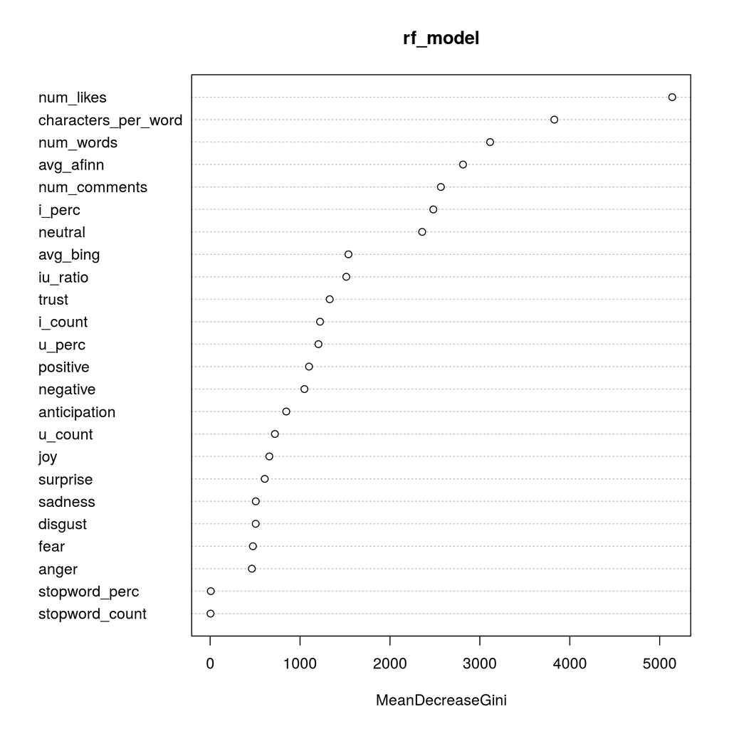

### What’s going on with Number of Likes?

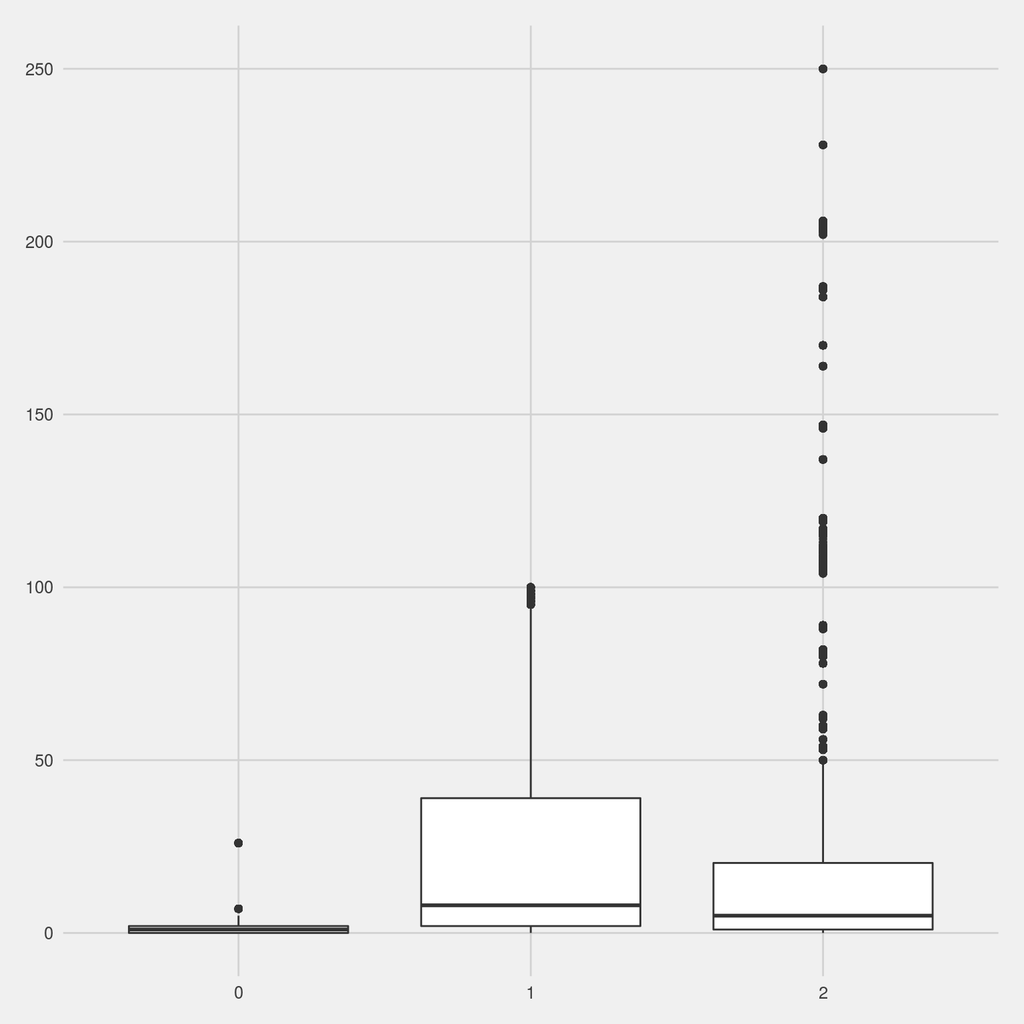

### Prediciton (Again). But, now without:

- Number of Likes
- Number of Comments
- Number of Words
- Characters per Word

| Model | Accuracy |
| --- | --- |
| Boosted Tree | 0.997 |
| Random Forest | 0.998 |
| Bagging | 0.998 |

### Importance Plot (Again)

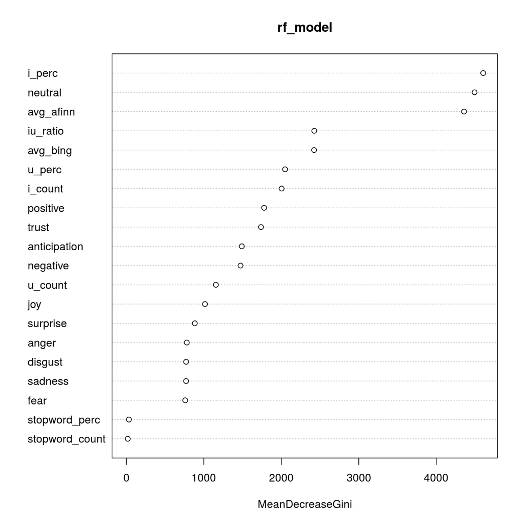

### One Last time… Now only including:

- NRC Sentiments (neutral, positive, negative, anger, anticipation, disgust, fear, joy, sadness, surprise, trust)
- Average Afinn Rating
- Average Bing Rating
- I-word to You-Word Ratio

| Model | Accuracy |
| --- | --- |
| Boosted Tree | 0.994 |
| Random Forest | 0.993 |
| Bagging | 0.994 |

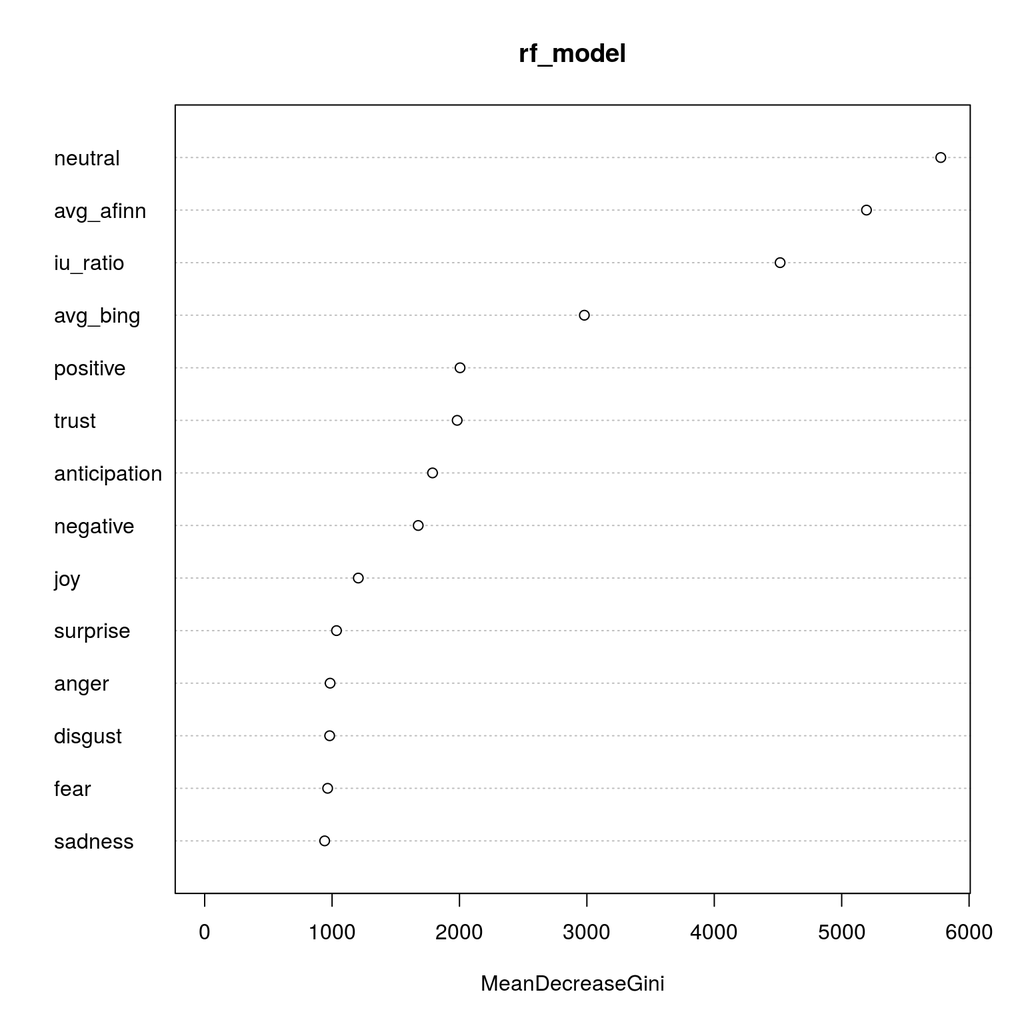

# Part 4: Unsupervised Learning

### Clustering: How many Clusters (where’s the elbow)?

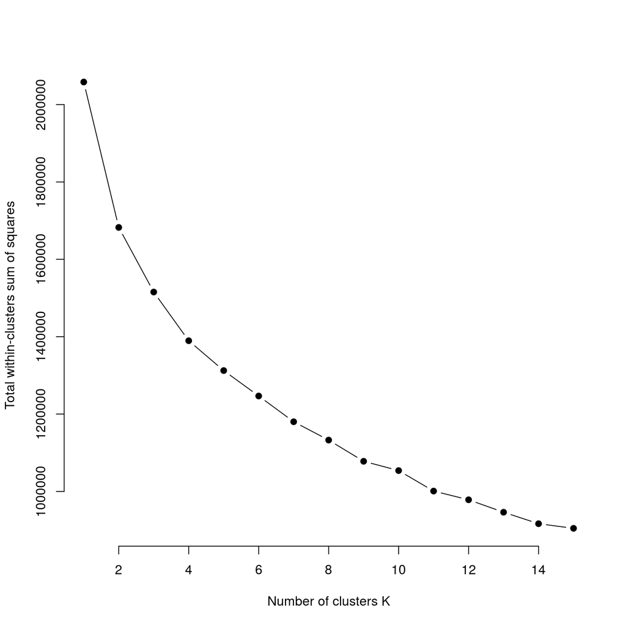

### We’ll go with 13 Clusters…

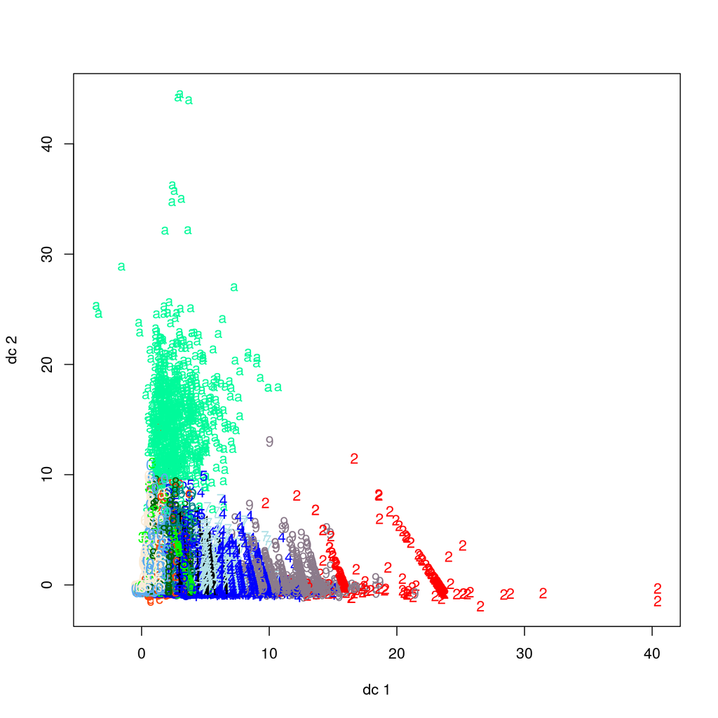

### Principal Components: What matters?

```
## Importance of components:
##                           PC1    PC2     PC3     PC4     PC5     PC6
## Standard deviation     2.4925 1.7779 0.98150 0.95856 0.76544 0.69849
## Proportion of Variance 0.4437 0.2258 0.06881 0.06563 0.04185 0.03485
## Cumulative Proportion  0.4437 0.6695 0.73835 0.80398 0.84583 0.88068
##                            PC7     PC8     PC9    PC10    PC11    PC12
## Standard deviation     0.60082 0.52062 0.51252 0.47676 0.40226 0.38574
## Proportion of Variance 0.02579 0.01936 0.01876 0.01624 0.01156 0.01063
## Cumulative Proportion  0.90647 0.92583 0.94459 0.96083 0.97238 0.98301
##                           PC13    PC14
## Standard deviation     0.35352 0.33592
## Proportion of Variance 0.00893 0.00806
## Cumulative Proportion  0.99194 1.00000
```

### Plotting the First Two Principal Components

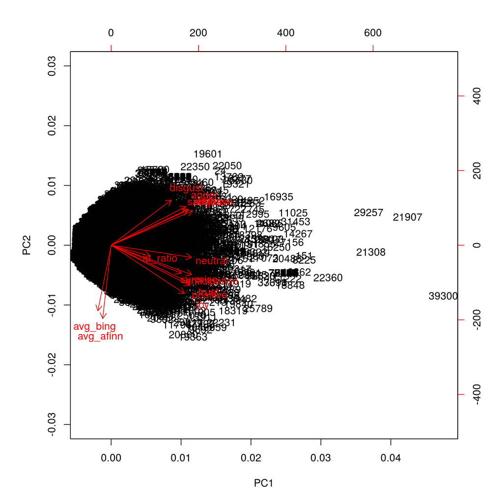

### First Principal Component

| variables | loadings |
| --- | --- |
| negative | 0.320 |
| anticipation | 0.316 |
| neutral | 0.315 |
| positive | 0.309 |
| trust | 0.306 |
| fear | 0.302 |
| sadness | 0.301 |
| anger | 0.293 |
| joy | 0.288 |
| surprise | 0.276 |
| disgust | 0.236 |
| iu_ratio | 0.154 |
| avg_afinn | -0.033 |
| avg_bing | -0.052 |

### Second Principal Component

| variables | loadings |
| --- | --- |
| disgust | 0.291 |
| anger | 0.249 |
| fear | 0.231 |
| sadness | 0.225 |
| negative | 0.221 |
| iu_ratio | -0.070 |
| neutral | -0.078 |
| surprise | -0.180 |
| anticipation | -0.189 |
| trust | -0.239 |
| positive | -0.259 |
| joy | -0.311 |
| avg_bing | -0.422 |
| avg_afinn | -0.472 |

# Part 5: Prediction (Last Time, Seriously)

### Using only NRC Sentiments

- neutral, positive, negative, anger, anticipation, disgust, fear, joy, sadness, surprise, trust

| Model | Accuracy |
| --- | --- |
| Boosted Tree | 0.939 |
| Random Forest | 0.911 |
| Bagging | 0.939 |

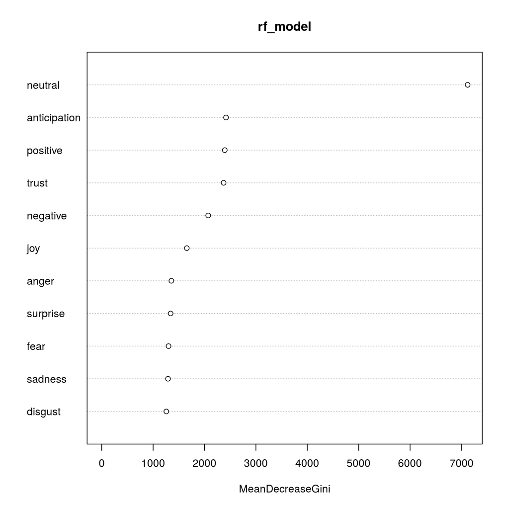

# Next Steps

- Further investigate the bias in our prediciton. (Seems [still?] too good to be true. Where’s the catch?)
- Investigate Canada. Why are they are so emotional?
- Be more ambitious in our prediction. Make it more granular (e.g. region, state, university or more countries)
- Topic Modeling